# Chapter 2: Polynomial Interpolation

# Polynomial Interpolation

In this chapter we study how to interpolate a data set with a polynomial.

**Problem Description**: Given (n+1) points, say(x<sub>i</sub>, y<sub>i</sub>), where i = 0,1,2,…,n, with distinct x<sub>i</sub>, not necessarily sorted, we want to find a polynomial of degree n:

$$P_n(x) = a_nx^n + a_{n-1}x^{n-1}+...+a_1x+a_0$$

such that it interpolates these points, i.e.,

$$P_n(x)= y_i, i = 0,1,2,...,n$$

The goal is the determine the coefficients $a_n, a_{n-1},...,a_1,a_0$. Note the total number of data poitns is 1 larger than the degree of the polynomial.

Why should we do this?

- Find the values between the points for discrete data set
- To approximate a (probably complicated) function by a polynomial
- Then, it is easier to do computations such as derivative, integrations, etc…

## Van Der Monde Matrix Example

Interpolate the given data set with a polynomial of degree 2:

$$\begin{tabular}{c|c|c|c|}
x$_i$ & 0 & 1 & 2/3\\
y$_i$ & 1 & 0 & 0.5
\end{tabular}$$

**Answer** Let

$$P_2(x) = a_2x^2 + a_1x+ a_0$$

We need to find the coefficients $a_2, a_1, a_0$. By the interpolating properties, we have 3 equations:

$$x = 0, y = 1 : P_2(0) = a_0 = 1$$
$$x = 1, y = 0 : P_2(1) = a_2+a_1+a_0 = 0$$
$$x = \frac23, y = 0.5 : P_2(\frac23) = (\frac49)a_2+(\frac23)a_1+a_0=0.5$$

Here we have 3 linear equations and 3 unknowns ($a_2, a_1, a_0$).

The equations:

In matrix-vector form:

$$\left(\begin{array}{ccc}
0 & 0 & 1\\
1 & 1 & 1\\
\frac49 & \frac23 & 1
\end{array}\right)
\left(\begin{array}{c}
a_0 \\
a_1 \\
a_2
\end{array}\right) =
\left(\begin{array}{c}
1 \\
0 \\
0.5
\end{array}\right)$$

Easy to solve in Matlab, or do it by hand:

$$a_2 = -\frac34$$
$$a_1 = -\frac14$$
$$a_0 = 1$$

Then

$$P_2(x) = -\frac34x^2 -\frac14x + 1$$

### The general case

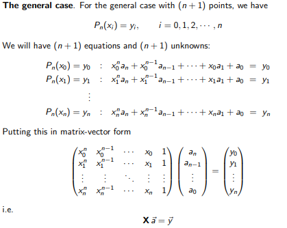

- X: a (n+1) x (n+1) matrix, given (Van Der Monde matrix)
- a: unknown vector, with length (n + 1)
- y: given vector, with length (n + 1)

**Theorem** If x<sub>i</sub>’s are distinct, then X is invertible, therefore a has a unique solution.

In Matlab, the command vander(x), where x is a vector that contains the interpolation points x = [$x_1, x_2, ...,x_n$], will generate this matrix.

Bad News: X has a very large condition number for large n, therefore not effective to solve if n is large.

## Lagrange Form

Given points: $x_0,x_1,...,x_n$

Define the **cardinal functions** $I_0,I_1,...,I_n:\in P^n$, satisfying the properties

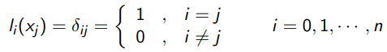

Here $\delta_{ij}$ is called the Kronecker’s delta.

Locally supported in discrete sense. The cardinal functions I_i(x) can be written as:

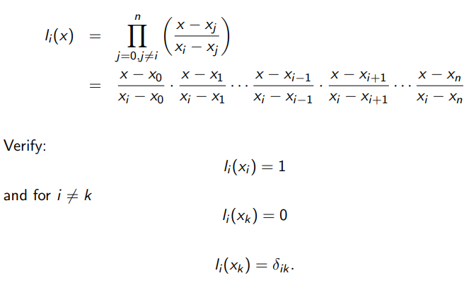

Lagrange form of the interpolation polynomial can be simply expressed as

$$P_n(x) = \Sigma I_j(x) * y_i$$

It is easy to check the interpolating property:

$$P_n(x_j) = \Sigma I_i(x_j) * y_i = y_j$$

for every j. (The cardinal function is 1 at x<sub>i</sub>, so y<sub>i</sub> is multiplied by 1).

**Example 2** Write the Lagrange polynomial for the data

$$\begin{tabular}{c|c|c|c|}
x$_i$ & 0 & 1 & 2/3\\
y$_i$ & 1 & 0 & 0.5
\end{tabular}$$

**Answer** We first ocmpute the cardinal functions

$$I_0(x) = \frac{(x-x_1)(x-x_2)}{(x_0-x_1)(x_0-x_2)} = \frac{(x-2/3)(x-1)}{(0-2/3)(0-1)} = \frac32(x - \frac23)(x-1)$$
$$I_1(x) = \frac{(x-x_0)(x-x_2)}{(x_1-x_0)(x_1-x_2)} = \frac{(x-0)(x-1)}{(2/3-0)(2/3-1)} = -\frac92x(x-1)$$
$$I_2(x) = \frac{(x-x_0)(x-x_1)}{(x_2-x_0)(x_2-x_1)} = \frac{(x-0)(x-2/3)}{(1-0)(1-2/3)} = 2x(x-\frac23)$$

so

$$P_2(x) = I_0(x)y_0+I_1(x)y_1+I_2(x)y_2 = \frac32(x - \frac23)(x-1) -\frac92x(x-1)(0.5) + 0 = -\frac34x^2-\frac14+1$$

Pros and cons of Lagrange polynomial:

- (+) Elegant Formula
- (-) Slow to compute, since each cardinal function is different
- (-) Not flexible: if one changes a point x<sub>j</sub>, or add on an additional point x<sub>n+1</sub>, one must recompute all cardinal functions.

## Newton’s divided differences

Given a data set:

$$\begin{tabular}{c|c|c|c|c|}
x$_i$ & x$_0$ & x$_1$ & ... & x$_n$\\
y$_i$ & y$_0$ & y$_1$ & ... & y$_n$
\end{tabular}$$

We will describe an algorithm in a recursive form.

**Main idea:**

Given $P_k(x)$ that interpolates k + 1 data points {$x_i, y_i$}, i = 0,1,2,…,k, compute $P_{k+1}(x)$ that interpolates one extra point, {$x_{k+1},y_{k+1}$}, by using P<sub>k</sub> and adding an extra term

For n = 0, we set $P_0(x) = y_0$. Then $P_0(x_0) = y_0$.

For n = 1, we set

$$P_1(x) = P_0(x) + a_1(x - x_0)$$

where a<sub>1</sub> is to be determined.

Then, $P_1(x_0) = P_0(x_0) + 0 = y_0$, for any a<sub>1</sub>.

Find a<sub>1</sub> by the interpolation property $y_1 = P_1(x_1)$, we have

$$y_1 = P_0(x_1) +a_1(x_1-x_0)=y+0+a_1(x_1-x_0)$$

This gives us

$$a_1 = \frac{y_1 - y_0}{x_1-x_0}$$

For n = 2, we set

$$P_2(x) = P_1(x) + a_2(x-x_0)(x-x_1)$$

Then $P_2(x_0) = P_1(x_0) = y_0, P_2(x_1) = P_1(x_1) = y_1$.

Determine a<sub>2</sub> by the interpolation property $y_2 = P_2(x_2)$

$$y_2 = P_1(x_2) + a_2(x_2 - x_0)(x_2-x_1)$$

Then

$$a_2 = \frac{y_2 - P_1(x_2)}{(x_2-x_0)(x_2-x_1)}$$

We would like to express a<sub>2</sub> in a different way. Recall

$$P_1(x) = y_0 + \frac{y_1-y_0}{x_1-x_0}(x - x_0)$$

Then

$$P_1(x_2) = y_0 + \frac{y_1-y_0}{x_1-x_0}(x_2 - x_0)$$
$$P_1(x_2) = y_0 + \frac{y_1-y_0}{x_1-x_0}(x_2 - x_1) + \frac{y_1-y_0}{x_1-x_0}(x_1 - x_0)$$
$$P_1(x_2) = y_1 + \frac{y_1-y_0}{x_1-x_0}(x_2 - x_1)$$

Then a<sub>2</sub> can be rewritten as

$$a_2 = \frac{y_2 - {P_1(x_2)}}{(x_2-x_0)(x_2-x_1)} = \frac{y_2-y_1-\frac{y_1-y_0}{x_1-x_0}(x_2-x_1)}{(x_2-x_0)(x_2-x_1)}=\frac{\frac{y_2-y_1}{x_2-x_1}-\frac{y_1-y_0}{x_1-x_0}}{x_2-x_0}$$

(Rise over the run? Secant lines represented…)

$$a_2 \approx \frac{f'(x_2)-f'(x_0)}{x_2-x_0} \approx f''()$$

and a_1 is an approximate first derivative.

### The general case:

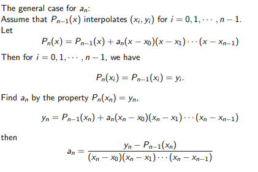

Newton’s form for the interpolation polynomial:

$$P_n(x) = a_0 + a_1(x - x_0) + a_2(x-x_0)(x-x_1)+...+a_n(x-x_0)(x-x_1)...(x-x_{n-1})$$

### Recursive Computation

The recursion is initiated with

$$f[x_i] = y_i, i = 0,1,2,...$$

Then

$$f[x_0,x_1] = \frac{f[x_1]-f[x_0]}{x_1-x_0}$$
$$f[x_1,x_2] = \frac{f[x_2]-f[x_1]}{x_2-x_1}$$
$$f[x_0,x_1,x_2] = \frac{f[x_1,x_2]-f[x_1,x_0]}{x_2-x_0}$$
$$f[x_0,x_1,x_2] = \frac{f[x_3,x_2]-f[x_2,x_1]}{x_3-x_1}$$

For the general step we have

$$f[x_0,x_1,...,x_k] = \frac{f[x_1,x_2,...,x_k] - f[x_0,x1_...,x_{k-1}]}{x_k-x_0}$$

The constants a<sub>k</sub>’s in the Newton’s form are computed as

$$a_0 = f[x_0]$$
$$a_1 = f[x_0,x_1]$$
$$...$$
$$a_k = f[x_0,x_1,...,x_k]$$

We compute f[…]’s through the following table:

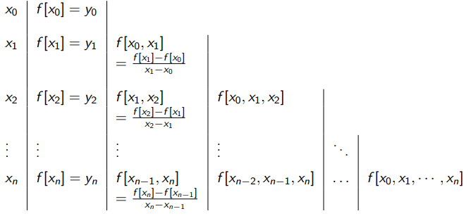

The diagonal elements give us the coefficients a<sub>i</sub>’s

### Example

Write Newton’s form of interpolation polynomial for the data

$$\begin{tabular}{c||c|c|c|c|}
x$_i$ & 0 & 1 & 2/3 & 1/3\\
y$_i$ & 1 & 0 & 1/2 & 0.866
\end{tabular}$$

**Answer** Set up the triangular table for computation

$$\begin{tabular}{c||c|c|c|c|}
0 & 1 & & & \\
1 & 0 & -1 & & \\
2/3 & 0.5 & -1.5 & -0.75 & \\
1/3 & 0.8660 & -1.0981 & -0.6029 & 0.4413
\end{tabular}$$

So we have

$$a_0 = 1, a_1 = -1, a_2 = -0.75, a_3 = 0.4413$$

Then

$$P_3(x) = 1 + -1x + -0.75x(x-1) + 0.4413x(x-1)x-\frac23)$$

**Flexibility** of Newton’s form: easy to add additional points to interpolate.

### Nested form of Newton’s Polynomial

$$P_n(x) = a_0 + a_1(x-x_0) + a_2(x-x_0)(x-x_1) + ...+a_n(x-x_0)(x-x_1)...(x-x_{n-1})$$
$$P_n(x) = a_0 + (x-x_0)(a_1 + (x-x_1)(a_2 + (x-x_2)(a_3 + ... + a_n(x-x_{n-1}))))$$

Effective coding:

Given the data x<sub>i</sub> and a<sub>i</sub> for i = 0,1,…,n the following pseudo-code evaluates Newton’s Polynomial $p = P_n(x)$

- p = a<sub>n</sub>
- for k = n-1,n-2,…,0
  - p = p(x-x_k) + a_k
- end

This requires only 3n flops.

## Existence and Uniqueness theorem for polynomial interpolation

**Theorem (Fundamental Theorem of Algebra)**

Every polynomial of degree n that is not identically zero, has maximum n roots (including multiplicities). These roots may be real or complex. In particular, this implies that if a polynomial of degree n has more than n roots, then it must be identically zero.

**Theorem (Existence and Uniqueness of Polynomial Interpolation)**

Given (x<sub>i</sub>, y<sub>i</sub>), with x<sub>i</sub>’s distinct. There exists one and only one polynomial P<sub>n</sub>(x) of degree $\leq n$ such that $P_n(x_i) = y_i$ for i = 0,1,…,n.

**Proof**

The existence: by construction. Uniqueness: Assume we have two polynomials $p(x),q(x) \in P_n$, such that

$$p(x_i) = y_i$$
$$q(x_i) = y_i$$
$$i = 0,1,...,n$$

Now, let $g(x) = p(x) - q(x)$, a polynomial of degree $\leq n$.

$$g(x_i) = p(x_i) - q(x_i) = y_i - y_i = 0$$
$$i = 0,1,...,n$$

So g(x) has n+1 zeros. By the Fundamental Theorem of Algebra (max n roots), we must have g(x) = 0, therefore p(x) is congruent to q(x).

# Errors in Polynomial Interpolation

Given a function f(x) on $x \in [a,b]$, and a set of distinct points $x_i \in [a,b]$, i = 0,1,…,n. Let $P_n(x) \in P_n$ such that..

$$P_n(x_i) = f(x_i),i=0,1,..,n$$

Error function

$$e(x) = f(x) - P_n(x), x\in [a,b]$$

**Theorem**. There exists some value $\xi \in [a,b]$, such that

$$e(x) = \frac1{(n+1)!}\xi\Pi(x-x_i),x\in [a,b]$$

**Proof**

If $f \in P_n$, then by Uniqueness Theorem of polynomial interpolation we must have $f(x) = P_n(x)$. Then e(x) == 0 and the proof is trivial.

Now assume $f \notin P_n(x)$. If $x=x_i$ for some i, we have $e(x_i) = f(x_i) - P_n(x_i) = 0$, and the results holds.

Now consider $x \neq x_i$ for any i.

$$W(x) = \Pi(x-x_i) \in P_{n+1}$$

it holds:

$$W(x_i) = 0$$
$$w(x) = x^{n+1}+...$$
$$W^{(n+1)} = (n+1)!$$

Fix a y such that $y \in [a,b]$ and $y \neq x_i$ for any i. We define a constant

$$c = \frac{f(y)-P_n(y)}{W(y)}$$

and another function

$$\phi(x) = f(x) - P_n(x) - cW(x)$$

We find all the zeros for $\phi(x)$. We see that x<sub>i</sub>’s are zeros since

$$\phi(x_i)=f(x_i)-P_n(x_i)-cW(x_i) = 0, i = 0,1,...,n$$

and also y is a zero because

$$\phi(y) = f(y) - P_n(y) -cW(y) = 0$$

So, $\phi$ has at least (n+2) zeros.

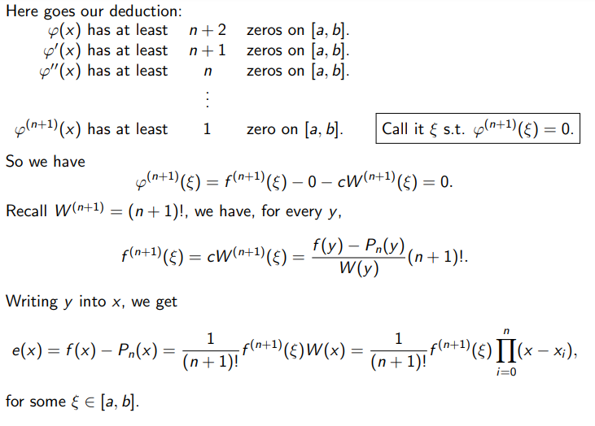

## Error fomula Example

Recall the error formula:

$$e(x) = \frac1{(n+1)!}\xi\Pi(x-x_i)$$

**Example** If n = 1, x<sub>0</sub> = a, x<sub>1</sub> = b, b > a, find an upper bound for error.

**Answer** Let

$$M = max|f''(x)| = ||f''(x)||_\infty$$

and observe

$$max|(x-a)(x-b)|=\frac{(b-a)^2}4$$

For $x \in [a,b]$, we have

$$|e(x)| = \frac12|f''(\xi)|*|(x-a)(x-b)| \leq \frac12||f''||_\infty\frac{(b-a)^2}4=\frac18||f''||_\infty(b-a)^2$$

Error depends on the distribution of nodes x<sub>i</sub>. If b is close to a, then we have a small error bound.

# Unifrom Grid

Equally distribute the nodes (x<sub>i</sub>): on [a,b], with n+1 nodes.

$$x_i = a + ih, h = \frac{b-a}n, i = 0,1,...,n$$

One can show that for $x \in [a,b]$, it holds

$$\Pi|x-x_i| \leq \frac14h^{n+1}*n!$$

**Proof** If x = x<sub>i</sub> for some i, then x-x<sub>i</sub> = 0 and the product is zero, so it trivially holds.

Now assume x<sub>i</sub> < x < x<sub>i+1</sub>. We have

$$max|(x-x_i)(x-x_{i+1}| = \frac14(x_{i+1}-x_i)^2=\frac{h^2}4$$

Now consider the other terms in the product, say x-x<sub>j</sub>, for either j > i + 1, or j < i. Then $|(x-x)j| \leq h(j-i)$ for j > i + 1 and $|(x-x)j| \leq h(i+1-j)$ for j < i. In all cases, the product of these terms are bounded by $h^{n-1}n!$, proving the result.

We have the error estimate

$$|e(x)| \leq \frac1{4(n+1)}|f^{(n+1)}(x)|h^{n+1}\leq\frac{M_{n+1}}{4(n+1)}h^{n+1}$$

where

$$M_{n+1} = max|f^{(n+1)}(x)|=||f^{(n+1)}||_\infty$$

**Example** Consider interpolating f(x) = sin($\pi$x) with polynomial on the interval [-1, 1] with uniform noes. Give an upper bound for error.

**Answer** Since

$$f'(x)=\pi cos \pi x$$
$$f''(x) = -\pi^2sin\pi x$$
$$f'''(x) = -pi^3cos\pi x$$

we have

$$|f^{(n+1)}(x)| \leq \pi^{n+1},M_{n+1}=\pi^{n+1}$$

so the upper bound for error is

$$|e(x)| \leq \frac{M_{n+1}}{4(n+1)}h^{n+1} \leq \frac{\pi^{n+1}}{4(n+1)}(\frac2n)^{n+1}$$

Simulation Data:

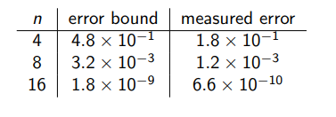

# Chebychev nodes: equally distributing the error

Type I: including the end points.

For interval [-1,1]: $\overline x_i = cos(\frac{i}{n}\pi), i = 0,1,...,n$

For interval [a,b] : $\overline x_i = \frac12(a+b) + \frac12(b-a)cos(\frac{i}{n}\pi), i = 0,1,...,n$

One can show that:

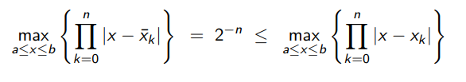

where x<sub>k</sub> is any other choice of nodes.

Error bound: $|e(x)| \leq \frac1{(n+1)!}|f^{(n+1)}(x)|2^{-n}$

**Example** Consider the same example with uniform nodes, $f(x) = sin\pi x$

With Chebyshev nodes, we have

$$|e(x)| \leq \frac1{(n+1)!}\pi^{n+1}2^{-n}$$

Now look at the much smaller error bounds!

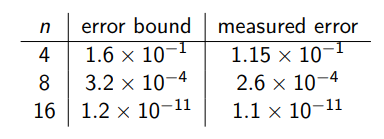

Type II: Chebyshev nodes can be chosen strictly inside the interval (a,b):

$$\overline x_i = \frac12(a+b) + \frac12(b-a)cos(\frac{2i+1}{2n+2}\pi),i=0,1,...,n$$

# Discussion

For large n, polynomials are heavy to deal with.

In general, interpolation polynomials do not coverge as n gets closer to infinity.

For small intervals, the error with polynomial interpolation is small.

Conclusion: Better to use piecewise polynomial interpolation - next chapter (splines). This uses polynomials of not so high power on smaller intervals.